# py_sklearn_multiclass_kaggle_tabular_playground_2021jun

### Multi-Class Model for Kaggle Tabular Playground Series June 2021 Using Python and Scikit-Learn

### July 12, 2021

Template Credit: Adapted from a template made available by Dr. Jason Brownlee of Machine Learning Mastery. [https://machinelearningmastery.com/]

SUMMARY: This project aims to construct a predictive model using various machine learning algorithms and document the end-to-end steps using a template. The Kaggle Tabular Playground June 2021 dataset is a multi-class modeling situation where we attempt to predict one of several (more than two) possible outcomes.

INTRODUCTION: Kaggle wants to provide an approachable environment for relatively new people in their data science journey. Since January 2021, they have hosted playground-style competitions on Kaggle with fun but less complex, tabular datasets. The dataset used for this competition is synthetic but based on a real dataset and generated using a CTGAN. The original dataset deals with predicting the category on an eCommerce product given various attributes about the listing. Although the features are anonymized, they have properties relating to real-world features.

ANALYSIS: The average performance of the machine learning algorithms achieved a logarithmic loss benchmark of 5.6058 using the training dataset. We selected Logistic Regression and Random Forest to perform the tuning exercises. After a series of tuning trials, the refined Random Forest model processed the training dataset with a final logarithmic loss score of 1.7700. When we processed Kaggle's test dataset with the final model, the model achieved a logarithmic loss score of 1.7682.

CONCLUSION: In this iteration, the Random Fores model appeared to be a suitable algorithm for modeling this dataset.

Dataset Used: Kaggle Tabular Playground 2021 June Data Set

Dataset ML Model: Multi-Class classification with categorical attributes

Dataset Reference: https://www.kaggle.com/c/tabular-playground-series-jun-2021/

One potential source of performance benchmark: https://www.kaggle.com/c/tabular-playground-series-jun-2021/leaderboard

Any predictive modeling machine learning project generally can be broken down into about six major tasks:

1. Prepare Environment
2. Summarize and Visualize Data
3. Pre-process Data
4. Train and Evaluate Models
5. Fine-tune and Improve Models
6. Finalize Model and Present Analysis

## Task 1 - Prepare Environment

```python
# Install the necessary packages for Colab
# !pip install python-dotenv PyMySQL
```

```python
# Retrieve the GPU information from Colab
# gpu_info = !nvidia-smi
# gpu_info = '\n'.join(gpu_info)
# if gpu_info.find('failed') >= 0:
#     print('Select the Runtime → "Change runtime type" menu to enable a GPU accelerator, ')
#     print('and then re-execute this cell.')
# else:
#     print(gpu_info)
```

```python
# Retrieve the memory configuration from Colab
# from psutil import virtual_memory
# ram_gb = virtual_memory().total / 1e9
# print('Your runtime has {:.1f} gigabytes of available RAM\n'.format(ram_gb))

# if ram_gb < 20:
#     print('To enable a high-RAM runtime, select the Runtime → "Change runtime type"')
#     print('menu, and then select High-RAM in the Runtime shape dropdown. Then, ')
#     print('re-execute this cell.')
# else:
#     print('You are using a high-RAM runtime!')
```

```python
# Retrieve the CPU information
ncpu = !nproc
print("The number of available CPUs is:", ncpu[0])
```

```
The number of available CPUs is: 6
```

### 1.a) Load libraries and modules

```python
# Set the random seed number for reproducible results
RNG_SEED = 888
```

```python
import numpy as np
import pandas as pd
import seaborn as sns
import matplotlib.pyplot as plt
import os
import sys
import math
from datetime import datetime
# import boto3
# from dotenv import load_dotenv
from sklearn import preprocessing
from sklearn.model_selection import train_test_split
from sklearn.model_selection import StratifiedKFold
from sklearn.model_selection import cross_val_score
from sklearn.model_selection import GridSearchCV
from sklearn.metrics import classification_report
from sklearn.metrics import confusion_matrix
from sklearn.metrics import accuracy_score
from sklearn.metrics import roc_auc_score
from sklearn.pipeline import Pipeline
from sklearn import compose
from sklearn import impute

from sklearn.linear_model import LogisticRegression
from sklearn.tree import DecisionTreeClassifier
from sklearn.neighbors import KNeighborsClassifier
from sklearn.ensemble import BaggingClassifier
from sklearn.ensemble import RandomForestClassifier
from sklearn.ensemble import ExtraTreesClassifier
from sklearn.ensemble import GradientBoostingClassifier
```

### 1.b) Set up the controlling parameters and functions

```python
# Begin the timer for the script processing
start_time_script = datetime.now()

# Set up the number of CPU cores available for multi-thread processing
N_JOBS = 2

# Set up the flag to stop sending progress emails (setting to True will send status emails!)
NOTIFY_STATUS = False

# Set the percentage sizes for splitting the dataset
TEST_SET_RATIO = 0.2
VAL_SET_RATIO = 0.25

# Set the number of folds for cross validation
N_FOLDS = 5

# Set various default modeling parameters
SCORING_METRIC = 'neg_log_loss'
```

```python
# Set up the email notification function
def status_notify(msg_text):
    access_key = os.environ.get('SNS_ACCESS_KEY')
    secret_key = os.environ.get('SNS_SECRET_KEY')
    aws_region = os.environ.get('SNS_AWS_REGION')
    topic_arn = os.environ.get('SNS_TOPIC_ARN')
    if (access_key is None) or (secret_key is None) or (aws_region is None):
        sys.exit("Incomplete notification setup info. Script Processing Aborted!!!")
    sns = boto3.client('sns', aws_access_key_id=access_key, aws_secret_access_key=secret_key, region_name=aws_region)
    response = sns.publish(TopicArn=topic_arn, Message=msg_text)
    if response['ResponseMetadata']['HTTPStatusCode'] != 200 :
        print('Status notification not OK with HTTP status code:', response['ResponseMetadata']['HTTPStatusCode'])
```

```python
if NOTIFY_STATUS: status_notify("Task 1 - Prepare Environment has begun! " + datetime.now().strftime('%a %B %d, %Y %I:%M:%S %p'))
```

### 1.c) Load dataset

```python
dataset_path = 'https://dainesanalytics.com/datasets/kaggle-tabular-playground-2021jun/train.csv'
df_dataset_import = pd.read_csv(dataset_path, index_col=False)

# Take a peek at the dataframe after import
print(df_dataset_import.head())
```

```
   id  feature_0  feature_1  feature_2  feature_3  feature_4  feature_5  \
0   0          0          0          6          1          0          0
1   1          0          0          0          0          0          0
2   2          0          0          0          0          0          1
3   3          0          0          7          0          1          5
4   4          1          0          0          0          0          0

   feature_6  feature_7  feature_8  ...  feature_66  feature_67  feature_68  \
0          0          0          7  ...           0           0           0
1          0          0          0  ...           2           0           0
2          0          3          0  ...           0           0           0
3          2          2          0  ...           0           4           0
4          0          0          0  ...           0           0           0

   feature_69  feature_70  feature_71  feature_72  feature_73  feature_74  \
0           0           0           0           2           0           0
1           0           0           0           0           1           0
2           0           1           0           0           0           0
3           2           2           0           4           3           0
4           0           0           0           0           0           0

    target
0  Class_6
1  Class_6
2  Class_2
3  Class_8
4  Class_2

[5 rows x 77 columns]
```

```python
df_dataset_import.info(verbose=True)
```

```
<class 'pandas.core.frame.DataFrame'>
RangeIndex: 200000 entries, 0 to 199999
Data columns (total 77 columns):
 #   Column      Non-Null Count   Dtype
---  ------      --------------   -----
 0   id          200000 non-null  int64
 1   feature_0   200000 non-null  int64
 2   feature_1   200000 non-null  int64
 3   feature_2   200000 non-null  int64
 4   feature_3   200000 non-null  int64
 5   feature_4   200000 non-null  int64
 6   feature_5   200000 non-null  int64
 7   feature_6   200000 non-null  int64
 8   feature_7   200000 non-null  int64
 9   feature_8   200000 non-null  int64
```

[output cut: 69 more lines]

```python
print(df_dataset_import.describe())
```

```
                  id      feature_0      feature_1      feature_2  \
count  200000.000000  200000.000000  200000.000000  200000.000000
mean    99999.500000       0.972710       1.168365       2.219325
std     57735.171256       3.941836       3.993407       6.476570
min         0.000000       0.000000       0.000000       0.000000
25%     49999.750000       0.000000       0.000000       0.000000
50%     99999.500000       0.000000       0.000000       0.000000
75%    149999.250000       1.000000       1.000000       1.000000
max    199999.000000      61.000000      51.000000      64.000000

           feature_3      feature_4      feature_5      feature_6  \
count  200000.000000  200000.000000  200000.000000  200000.000000
mean        2.296735       0.793530       1.431105       1.010695
std         7.551858       2.935785       5.162746       3.949231
min         0.000000       0.000000       0.000000       0.000000
25%         0.000000       0.000000       0.000000       0.000000
50%         0.000000       0.000000       0.000000       0.000000
75%         1.000000       0.000000       1.000000       0.000000
max        70.000000      38.000000      76.000000      43.000000

           feature_7     feature_8  ...     feature_65     feature_66  \
count  200000.000000  200000.00000  ...  200000.000000  200000.000000
mean        0.673090       1.94398  ...       1.798040       0.508695
std         2.234949       3.93133  ...       5.053014       1.867330
min         0.000000       0.00000  ...       0.000000       0.000000
25%         0.000000       0.00000  ...       0.000000       0.000000
50%         0.000000       0.00000  ...       0.000000       0.000000
75%         0.000000       2.00000  ...       1.000000       0.000000
max        30.000000      38.00000  ...      54.000000      24.000000

          feature_67     feature_68     feature_69     feature_70  \
count  200000.000000  200000.000000  200000.000000  200000.000000
mean        1.827300       0.910370       1.603585       1.219210
std         7.188924       3.835182       4.877679       4.826003
min         0.000000       0.000000       0.000000       0.000000
25%         0.000000       0.000000       0.000000       0.000000
50%         0.000000       0.000000       0.000000       0.000000
75%         1.000000       1.000000       2.000000       1.000000
max        79.000000      55.000000      65.000000      67.000000

          feature_71     feature_72    feature_73     feature_74
count  200000.000000  200000.000000  200000.00000  200000.000000
mean        0.806895       1.282925       2.94021       0.632005
std         2.458741       4.261420      10.78465       3.925310
min         0.000000       0.000000       0.00000       0.000000
25%         0.000000       0.000000       0.00000       0.000000
50%         0.000000       0.000000       0.00000       0.000000
75%         1.000000       1.000000       1.00000       0.000000
max        30.000000      61.000000     130.00000      52.000000

[8 rows x 76 columns]
```

```python
print(df_dataset_import.isnull().sum())
print('Total number of NaN in the dataframe: ', df_dataset_import.isnull().sum().sum())
```

```
id            0
feature_0     0
feature_1     0
feature_2     0
feature_3     0
             ..
feature_71    0
feature_72    0
feature_73    0
feature_74    0
target        0
Length: 77, dtype: int64
Total number of NaN in the dataframe:  0
```

### 1.d) Data Cleaning

```python
# Dropping features
df_dataset_import.drop(columns=['id'], inplace=True)

# # Convert columns from one data type to another
# train_feature_list = list(df_dataset_import.columns)
# for feature in train_feature_list:
#     df_dataset_import[feature] = df_dataset_import[feature].astype('category')

# Take a peek at the dataframe after cleaning
print(df_dataset_import.head())
```

```
   feature_0  feature_1  feature_2  feature_3  feature_4  feature_5  \
0          0          0          6          1          0          0
1          0          0          0          0          0          0
2          0          0          0          0          0          1
3          0          0          7          0          1          5
4          1          0          0          0          0          0

   feature_6  feature_7  feature_8  feature_9  ...  feature_66  feature_67  \
0          0          0          7          0  ...           0           0
1          0          0          0          0  ...           2           0
2          0          3          0          0  ...           0           0
3          2          2          0          1  ...           0           4
4          0          0          0          0  ...           0           0

   feature_68  feature_69  feature_70  feature_71  feature_72  feature_73  \
0           0           0           0           0           2           0
1           0           0           0           0           0           1
2           0           0           1           0           0           0
3           0           2           2           0           4           3
4           0           0           0           0           0           0

   feature_74   target
0           0  Class_6
1           0  Class_6
2           0  Class_2
3           0  Class_8
4           0  Class_2

[5 rows x 76 columns]
```

```python
df_dataset_import.info(verbose=True)
```

```
<class 'pandas.core.frame.DataFrame'>
RangeIndex: 200000 entries, 0 to 199999
Data columns (total 76 columns):
 #   Column      Non-Null Count   Dtype
---  ------      --------------   -----
 0   feature_0   200000 non-null  int64
 1   feature_1   200000 non-null  int64
 2   feature_2   200000 non-null  int64
 3   feature_3   200000 non-null  int64
 4   feature_4   200000 non-null  int64
 5   feature_5   200000 non-null  int64
 6   feature_6   200000 non-null  int64
 7   feature_7   200000 non-null  int64
 8   feature_8   200000 non-null  int64
 9   feature_9   200000 non-null  int64
```

[output cut: 68 more lines]

```python
print(df_dataset_import.describe())
```

```
           feature_0      feature_1      feature_2      feature_3  \
count  200000.000000  200000.000000  200000.000000  200000.000000
mean        0.972710       1.168365       2.219325       2.296735
std         3.941836       3.993407       6.476570       7.551858
min         0.000000       0.000000       0.000000       0.000000
25%         0.000000       0.000000       0.000000       0.000000
50%         0.000000       0.000000       0.000000       0.000000
75%         1.000000       1.000000       1.000000       1.000000
max        61.000000      51.000000      64.000000      70.000000

           feature_4      feature_5      feature_6      feature_7  \
count  200000.000000  200000.000000  200000.000000  200000.000000
mean        0.793530       1.431105       1.010695       0.673090
std         2.935785       5.162746       3.949231       2.234949
min         0.000000       0.000000       0.000000       0.000000
25%         0.000000       0.000000       0.000000       0.000000
50%         0.000000       0.000000       0.000000       0.000000
75%         0.000000       1.000000       0.000000       0.000000
max        38.000000      76.000000      43.000000      30.000000

          feature_8      feature_9  ...     feature_65     feature_66  \
count  200000.00000  200000.000000  ...  200000.000000  200000.000000
mean        1.94398       1.719655  ...       1.798040       0.508695
std         3.93133       5.916988  ...       5.053014       1.867330
min         0.00000       0.000000  ...       0.000000       0.000000
25%         0.00000       0.000000  ...       0.000000       0.000000
50%         0.00000       0.000000  ...       0.000000       0.000000
75%         2.00000       1.000000  ...       1.000000       0.000000
max        38.00000      72.000000  ...      54.000000      24.000000

          feature_67     feature_68     feature_69     feature_70  \
count  200000.000000  200000.000000  200000.000000  200000.000000
mean        1.827300       0.910370       1.603585       1.219210
std         7.188924       3.835182       4.877679       4.826003
min         0.000000       0.000000       0.000000       0.000000
25%         0.000000       0.000000       0.000000       0.000000
50%         0.000000       0.000000       0.000000       0.000000
75%         1.000000       1.000000       2.000000       1.000000
max        79.000000      55.000000      65.000000      67.000000

          feature_71     feature_72    feature_73     feature_74
count  200000.000000  200000.000000  200000.00000  200000.000000
mean        0.806895       1.282925       2.94021       0.632005
std         2.458741       4.261420      10.78465       3.925310
min         0.000000       0.000000       0.00000       0.000000
25%         0.000000       0.000000       0.00000       0.000000
50%         0.000000       0.000000       0.00000       0.000000
75%         1.000000       1.000000       1.00000       0.000000
max        30.000000      61.000000     130.00000      52.000000

[8 rows x 75 columns]
```

```python
print(df_dataset_import.isnull().sum())
print('Total number of NaN in the dataframe: ', df_dataset_import.isnull().sum().sum())
```

```
feature_0     0
feature_1     0
feature_2     0
feature_3     0
feature_4     0
             ..
feature_71    0
feature_72    0
feature_73    0
feature_74    0
target        0
Length: 76, dtype: int64
Total number of NaN in the dataframe:  0
```

### 1.e) Splitting Data into Sets

```python
# Use variable total_column_count to hold the number of columns in the dataframe
total_column_count = len(df_dataset_import.columns)

# Set up variable total_feature_count for the total number of attribute columns
total_feature_count = total_column_count-1

# target_column_position variable indicates the column location of the target/class variable
# If the first column, set target_column_position to 1. If the last column, set target_column_position to total_column_count
# If (target_column_position <> 1) and (target_column_position <> total_column_count), be aware when slicing up the dataframes for visualization
target_column_position = total_column_count
```

```python
# We create attribute-only and target-only datasets (df_features_train and df_target_train)
# for various visualization and cleaning/transformation operations

if target_column_position == total_column_count:
    df_features_train = df_dataset_import.iloc[:,0:total_feature_count]
    df_target_train = df_dataset_import.iloc[:,total_feature_count]
else:
    df_features_train = df_dataset_import.iloc[:,1:total_column_count]
    df_target_train = df_dataset_import.iloc[:,0]

print("df_dataset_import.shape: {} df_features_train.shape: {} df_target_train.shape: {}".format(df_dataset_import.shape, df_features_train.shape, df_target_train.shape))
```

```
df_dataset_import.shape: (200000, 76) df_features_train.shape: (200000, 75) df_target_train.shape: (200000,)
```

### 1.f) Set up the parameters for data visualization

```python
# Set up the number of row and columns for visualization display. display_rows * display_columns should be >= total_feature_count
display_columns = 4
if total_feature_count % display_columns == 0 :
    display_rows = total_feature_count // display_columns
else :
    display_rows = (total_feature_count // display_columns) + 1

# Set figure width to display the data visualization plots
fig_size = plt.rcParams["figure.figsize"]
fig_size[0] = display_columns * 4
fig_size[1] = display_rows * 4
plt.rcParams["figure.figsize"] = fig_size
```

```python
if NOTIFY_STATUS: status_notify("Task 1 - Prepare Environment completed! "+datetime.now().strftime('%a %B %d, %Y %I:%M:%S %p'))
```

## Task 2 - Summarize and Visualize Data

```python
if NOTIFY_STATUS: status_notify("Task 2 - Summarize and Visualize Data has begun! "+datetime.now().strftime('%a %B %d, %Y %I:%M:%S %p'))
```

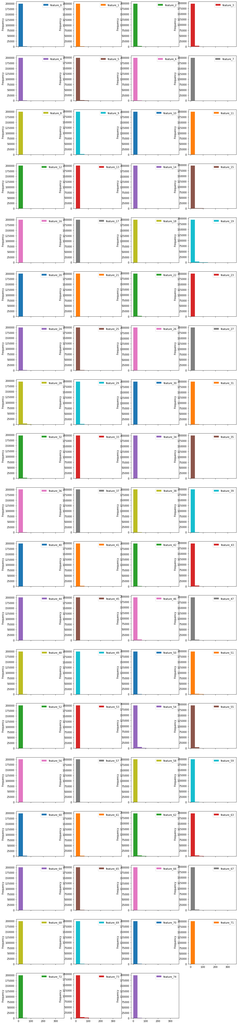

```python
# Histograms for each attribute
df_features_train.plot(kind='hist', subplots=True, layout=(display_rows, display_columns))
plt.show()
```

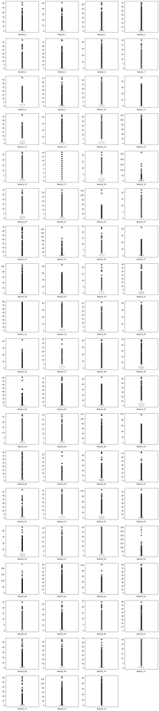

```python
# Box and Whisker plot for each attribute
df_features_train.plot(kind='box', subplots=True, layout=(display_rows, display_columns))
plt.show()
```

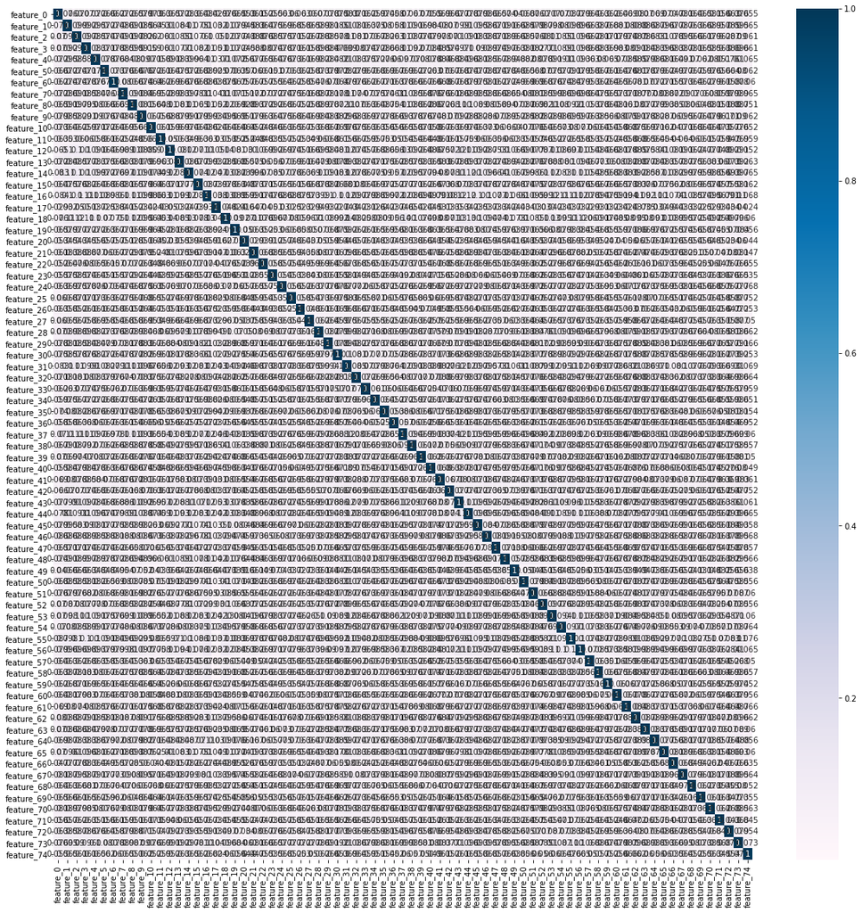

```python
# Correlation matrix
fig = plt.figure(figsize=(20, 20))
correlations = df_features_train.corr(method='pearson')
sns.heatmap(correlations, annot=True, cmap=plt.cm.PuBu)
plt.show()
```

```python
if NOTIFY_STATUS: status_notify("Task 2 - Summarize and Visualize Data completed! "+datetime.now().strftime('%a %B %d, %Y %I:%M:%S %p'))
```

## Task 3 - Pre-process Data

```python
if NOTIFY_STATUS: status_notify("Task 3 - Pre-process Data has begun! "+datetime.now().strftime('%a %B %d, %Y %I:%M:%S %p'))
```

### 3.a) Splitting Data into Training and Test Sets

```python
# Not applicable for this iteration of the project
```

### 3.b) Feature Scaling and Data Pre-Processing

```python
# Compose pipeline for the numerical and categorical features (Block #1 of 2)
numeric_columns = df_features_train.select_dtypes(include=['int64','float64']).columns
numeric_transformer = Pipeline(steps=[
#     ('imputer', impute.SimpleImputer(strategy="median")),
    ('scaler', preprocessing.MinMaxScaler())
])
categorical_columns = df_features_train.select_dtypes(include=['object','bool','category']).columns
categorical_transformer = Pipeline(steps=[
#     ('imputer', impute.SimpleImputer(strategy='constant', fill_value='UKNOWN')),
    ('onehot', preprocessing.OneHotEncoder(sparse=False, handle_unknown='ignore'))
])

print("Number of numerical columns:", len(numeric_columns))
print("Number of categorical columns:", len(categorical_columns))
print("Total number of columns in the feature dataframe:", df_features_train.shape[1])
```

```
Number of numerical columns: 75
Number of categorical columns: 0
Total number of columns in the feature dataframe: 75
```

```python
# Compose pipeline for the numerical and categorical features (Block #2 of 2)
preprocessor = compose.ColumnTransformer(transformers=[
    ('num', numeric_transformer, numeric_columns),
    ('cat', categorical_transformer, categorical_columns)
])

# Display the shapes of the training dataset for final inspection
array_features_train = preprocessor.fit_transform(df_features_train)
print("Transformed features from df_features_train.shape: {} to array_features_train.shape: {}".format(df_features_train.shape, array_features_train.shape))
```

```
Transformed features from df_features_train.shape: (200000, 75) to array_features_train.shape: (200000, 75)
```

### 3.c) Training Data Balancing

```python
# Not applicable for this iteration of the project
```

### 3.d) Feature Selection

```python
# Not applicable for this iteration of the project
```

### 3.e) Display the Final Datasets for Model-Building

```python
# Finalize the training and validation datasets for the modeling activities
# array_features_train = df_features_train.to_numpy()
label_encoder = preprocessing.LabelEncoder()
array_target_train = label_encoder.fit_transform(df_target_train)
print(label_encoder.classes_)
print("array_features_train.shape: {} array_target_train.shape: {}".format(array_features_train.shape, array_target_train.shape))
```

[output not shown]

```python
if NOTIFY_STATUS: status_notify("Task 3 - Pre-process Data completed! "+datetime.now().strftime('%a %B %d, %Y %I:%M:%S %p'))
```

## Task 4 - Train and Evaluate Models

```python
if NOTIFY_STATUS: status_notify("Task 4 - Train and Evaluate Models has begun! "+datetime.now().strftime('%a %B %d, %Y %I:%M:%S %p'))
```

### 4.a) Set test options and evaluation metric

```python
# Set up Algorithms Spot-Checking Array
start_time_training = datetime.now()
start_time_module = datetime.now()
train_models = []
train_results = []
train_model_names = []
train_metrics = []
train_models.append(('LGR', LogisticRegression(random_state=RNG_SEED, n_jobs=N_JOBS)))
# train_models.append(('CART', DecisionTreeClassifier(random_state=RNG_SEED)))
train_models.append(('KNN', KNeighborsClassifier(n_jobs=N_JOBS)))
train_models.append(('BGT', BaggingClassifier(random_state=RNG_SEED, n_jobs=N_JOBS)))
train_models.append(('RNF', RandomForestClassifier(random_state=RNG_SEED, n_jobs=N_JOBS)))
train_models.append(('EXT', ExtraTreesClassifier(random_state=RNG_SEED, n_jobs=N_JOBS)))
```

```python
# Generate model in turn
for name, model in train_models:
	if NOTIFY_STATUS: status_notify("Algorithm "+name+" modeling has begun! "+datetime.now().strftime('%a %B %d, %Y %I:%M:%S %p'))
	start_time_module = datetime.now()
	kfold = StratifiedKFold(n_splits=N_FOLDS, shuffle=True, random_state=RNG_SEED)
	cv_results = cross_val_score(model, array_features_train, array_target_train, cv=kfold, scoring=SCORING_METRIC, n_jobs=N_JOBS, verbose=1)
	train_results.append(cv_results)
	train_model_names.append(name)
	train_metrics.append(cv_results.mean())
	print("%s: %f (%f)" % (name, cv_results.mean(), cv_results.std()))
	print(model)
	print ('Model training time:', (datetime.now() - start_time_module), '\n')
	if NOTIFY_STATUS: status_notify("Algorithm "+name+" modeling completed! "+datetime.now().strftime('%a %B %d, %Y %I:%M:%S %p'))
print ('Average metrics ('+SCORING_METRIC+') from all models:',np.mean(train_metrics))
print ('Total training time for all models:',(datetime.now() - start_time_training))
```

```
[Parallel(n_jobs=2)]: Using backend LokyBackend with 2 concurrent workers.
[Parallel(n_jobs=2)]: Done   5 out of   5 | elapsed:  2.2min finished
[Parallel(n_jobs=2)]: Using backend LokyBackend with 2 concurrent workers.
```

```
LGR: -1.828581 (0.002447)
LogisticRegression(n_jobs=2, random_state=888)
Model training time: 0:02:09.387467
```

```
[Parallel(n_jobs=2)]: Done   5 out of   5 | elapsed: 15.8min finished
[Parallel(n_jobs=2)]: Using backend LokyBackend with 2 concurrent workers.
```

```
KNN: -13.848221 (0.077282)
KNeighborsClassifier(n_jobs=2)
Model training time: 0:15:49.458313
```

```
[Parallel(n_jobs=2)]: Done   5 out of   5 | elapsed:  2.3min finished
[Parallel(n_jobs=2)]: Using backend LokyBackend with 2 concurrent workers.
```

```
BGT: -8.321099 (0.057192)
BaggingClassifier(n_jobs=2, random_state=888)
Model training time: 0:02:20.869794
```

```
[Parallel(n_jobs=2)]: Done   5 out of   5 | elapsed:  3.1min finished
[Parallel(n_jobs=2)]: Using backend LokyBackend with 2 concurrent workers.
```

```
RNF: -2.010213 (0.017461)
RandomForestClassifier(n_jobs=2, random_state=888)
Model training time: 0:03:07.033189

EXT: -2.020928 (0.010553)
ExtraTreesClassifier(n_jobs=2, random_state=888)
Model training time: 0:03:57.959334

Average metrics (neg_log_loss) from all models: -5.605808393950472
Total training time for all models: 0:27:24.734557
```

```
[Parallel(n_jobs=2)]: Done   5 out of   5 | elapsed:  4.0min finished
```

### 4.b) Spot-checking baseline algorithms

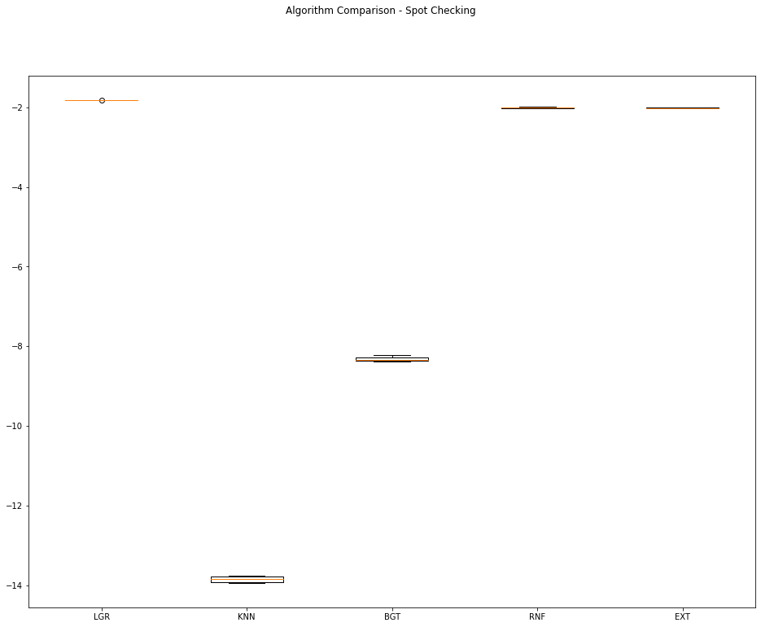

```python
fig = plt.figure(figsize=(16,12))
fig.suptitle('Algorithm Comparison - Spot Checking')
ax = fig.add_subplot(111)
plt.boxplot(train_results)
ax.set_xticklabels(train_model_names)
plt.show()
```

```python
if NOTIFY_STATUS: status_notify("Task 4 - Train and Evaluate Models completed! "+datetime.now().strftime('%a %B %d, %Y %I:%M:%S %p'))
```

## Task 5 - Fine-tune and Improve Models

```python
if NOTIFY_STATUS: status_notify("Task 5 - Fine-tune and Improve Models has begun! "+datetime.now().strftime('%a %B %d, %Y %I:%M:%S %p'))
```

### 5.a) Algorithm Tuning

```python
# Set up the comparison array
tune_results = []
tune_model_names = []
```

```python
# Tuning algorithm #1 - Extra Trees
start_time_module = datetime.now()
if NOTIFY_STATUS: status_notify("Algorithm #1 tuning has begun! "+datetime.now().strftime('%a %B %d, %Y %I:%M:%S %p'))

tune_model1 = LogisticRegression(random_state=RNG_SEED, n_jobs=N_JOBS)
tune_model_names.append('LGR')
paramGrid1 = dict(C=np.array([1, 0.1, 0.01, 0.001]))

kfold = StratifiedKFold(n_splits=N_FOLDS, shuffle=True, random_state=RNG_SEED)
grid1 = GridSearchCV(estimator=tune_model1, param_grid=paramGrid1, scoring=SCORING_METRIC, cv=kfold, n_jobs=N_JOBS, verbose=1)
grid_result1 = grid1.fit(array_features_train, array_target_train)

print("Best: %f using %s" % (grid_result1.best_score_, grid_result1.best_params_))
tune_results.append(grid_result1.cv_results_['mean_test_score'])
means = grid_result1.cv_results_['mean_test_score']
stds = grid_result1.cv_results_['std_test_score']
params = grid_result1.cv_results_['params']
for mean, stdev, param in zip(means, stds, params):
    print("%f (%f) with: %r" % (mean, stdev, param))
print ('Model training time:',(datetime.now() - start_time_module))
if NOTIFY_STATUS: status_notify("Algorithm #1 tuning completed! "+datetime.now().strftime('%a %B %d, %Y %I:%M:%S %p'))
```

```
Fitting 5 folds for each of 4 candidates, totalling 20 fits
Best: -1.828227 using {'C': 0.1}
-1.828581 (0.002447) with: {'C': 1.0}
-1.828227 (0.002300) with: {'C': 0.1}
-1.832341 (0.001728) with: {'C': 0.01}
-1.861015 (0.000758) with: {'C': 0.001}
Model training time: 0:06:12.556266
```

```python
best_paramKey1 = list(grid_result1.best_params_.keys())[0]
best_paramValue1 = list(grid_result1.best_params_.values())[0]
print("Captured the best parameter for algorithm #1:", best_paramKey1, '=', best_paramValue1)
```

```
Captured the best parameter for algorithm #1: C = 0.1
```

```python
# Tuning algorithm #2 - Random Forest
start_time_module = datetime.now()
if NOTIFY_STATUS: status_notify("Algorithm #2 tuning has begun! "+datetime.now().strftime('%a %B %d, %Y %I:%M:%S %p'))

tune_model2 = RandomForestClassifier(random_state=RNG_SEED, n_jobs=N_JOBS)
tune_model_names.append('RNF')
paramGrid2 = dict(n_estimators=np.array([100, 250, 500, 750]))

kfold = StratifiedKFold(n_splits=N_FOLDS, shuffle=True, random_state=RNG_SEED)
grid2 = GridSearchCV(estimator=tune_model2, param_grid=paramGrid2, scoring=SCORING_METRIC, cv=kfold, n_jobs=N_JOBS, verbose=1)
grid_result2 = grid2.fit(array_features_train, array_target_train)

print("Best: %f using %s" % (grid_result2.best_score_, grid_result2.best_params_))
tune_results.append(grid_result2.cv_results_['mean_test_score'])
means = grid_result2.cv_results_['mean_test_score']
stds = grid_result2.cv_results_['std_test_score']
params = grid_result2.cv_results_['params']
for mean, stdev, param in zip(means, stds, params):
    print("%f (%f) with: %r" % (mean, stdev, param))
print ('Model training time:',(datetime.now() - start_time_module))
if NOTIFY_STATUS: status_notify("Algorithm #2 tuning completed! "+datetime.now().strftime('%a %B %d, %Y %I:%M:%S %p'))
```

```
Fitting 5 folds for each of 4 candidates, totalling 20 fits
Best: -1.770084 using {'n_estimators': 750}
-2.010213 (0.017461) with: {'n_estimators': 100}
-1.802818 (0.003122) with: {'n_estimators': 250}
-1.775261 (0.002535) with: {'n_estimators': 500}
-1.770084 (0.002498) with: {'n_estimators': 750}
Model training time: 0:54:52.040946
```

```python
best_paramKey2 = list(grid_result2.best_params_.keys())[0]
best_paramValue2 = list(grid_result2.best_params_.values())[0]
print("Captured the best parameter for algorithm #2:", best_paramKey2, '=', best_paramValue2)
```

```
Captured the best parameter for algorithm #2: n_estimators = 750
```

### 5.b) Compare Algorithms After Tuning

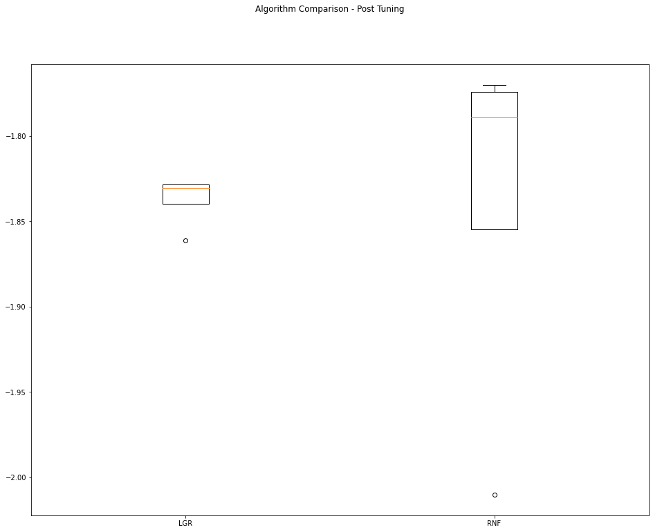

```python
fig = plt.figure(figsize=(16,12))
fig.suptitle('Algorithm Comparison - Post Tuning')
ax = fig.add_subplot(111)
plt.boxplot(tune_results)
ax.set_xticklabels(tune_model_names)
plt.show()
```

```python
if NOTIFY_STATUS: status_notify("Task 5 - Fine-tune and Improve Models completed! "+datetime.now().strftime('%a %B %d, %Y %I:%M:%S %p'))
```

## Task 6 - Finalize Model and Present Analysis

```python
if NOTIFY_STATUS: status_notify("Task 6 - Finalize Model and Present Analysis has begun! "+datetime.now().strftime('%a %B %d, %Y %I:%M:%S %p'))
```

### 6.a) Train the Final Model

```python
final_model = RandomForestClassifier(n_estimators=best_paramValue2, random_state=RNG_SEED, n_jobs=N_JOBS)
final_model.fit(array_features_train, array_target_train)
print(final_model)
```

```
RandomForestClassifier(n_estimators=750, n_jobs=2, random_state=888)
```

### 6.b) Load Test Dataset and Prepare the Submission File

```python
dataset_path = 'https://dainesanalytics.com/datasets/kaggle-tabular-playground-2021jun/test.csv'
df_features_test = pd.read_csv(dataset_path, index_col=False)

# Take a peek at the dataframe after import
print(df_features_test.head())
```

```
       id  feature_0  feature_1  feature_2  feature_3  feature_4  feature_5  \
0  200000          0          0          0          0          0          0
1  200001          1          2          0          0          0          0
2  200002          0          1          7          1          0          0
3  200003          0          0          0          4          3          1
4  200004          0          0          5          0          0          0

   feature_6  feature_7  feature_8  ...  feature_65  feature_66  feature_67  \
0          0          0          0  ...           0           0           0
1          0          0          0  ...           3           1           3
2          0          0          6  ...           3           0           0
3          0          0          0  ...           0           0           0
4          0          0          0  ...           0           0           0

   feature_68  feature_69  feature_70  feature_71  feature_72  feature_73  \
0           0           0           0           0           0           0
1           0           0           0           0           3           0
2           0           0           3           0           2           0
3           1           0           0           0           4           0
4           0           0           0           0           0           1

   feature_74
0           0
1           0
2           0
3           0
4           0

[5 rows x 76 columns]
```

```python
df_kaggle_submission = pd.DataFrame()
df_kaggle_submission['id'] = df_features_test['id']
print(df_kaggle_submission.head())
```

```
       id
0  200000
1  200001
2  200002
3  200003
4  200004
```

```python
# Dropping features
df_features_test.drop(columns=['id'], inplace=True)

# # Convert columns from one data type to another
# test_feature_list = list(df_features_test.columns)
# for feature in test_feature_list:
#     df_features_test[feature] = df_features_test[feature].astype('category')

# Take a peek at the dataframe after cleaning
print(df_features_test.head())
```

```
   feature_0  feature_1  feature_2  feature_3  feature_4  feature_5  \
0          0          0          0          0          0          0
1          1          2          0          0          0          0
2          0          1          7          1          0          0
3          0          0          0          4          3          1
4          0          0          5          0          0          0

   feature_6  feature_7  feature_8  feature_9  ...  feature_65  feature_66  \
0          0          0          0          0  ...           0           0
1          0          0          0          0  ...           3           1
2          0          0          6          0  ...           3           0
3          0          0          0          0  ...           0           0
4          0          0          0          8  ...           0           0

   feature_67  feature_68  feature_69  feature_70  feature_71  feature_72  \
0           0           0           0           0           0           0
1           3           0           0           0           0           3
2           0           0           0           3           0           2
3           0           1           0           0           0           4
4           0           0           0           0           0           0

   feature_73  feature_74
0           0           0
1           0           0
2           0           0
3           0           0
4           1           0

[5 rows x 75 columns]
```

```python
# Finalize the test dataset for the modeling testing
array_features_test = preprocessor.transform(df_features_test)
print("Transformed features from df_features_test.shape: {} to array_features_test.shape: {}".format(df_features_test.shape, array_features_test.shape))
```

```
Transformed features from df_features_test.shape: (100000, 75) to array_features_test.shape: (100000, 75)
```

```python
# Make batched predictions
test_predictions = final_model.predict_proba(array_features_test)
print(test_predictions)
```

```
[[0.02666667 0.58789524 0.15216825 ... 0.01066667 0.00666667 0.05060317]
 [0.05066667 0.14133333 0.06666667 ... 0.052      0.23733333 0.13333333]
 [0.01866667 0.07066667 0.04666667 ... 0.04666667 0.13733333 0.08266667]
 ...
 [0.08133333 0.25066667 0.14933333 ... 0.02133333 0.08933333 0.188     ]
 [0.04533333 0.03466667 0.044      ... 0.06533333 0.31333333 0.1       ]
 [0.05333333 0.096      0.06266667 ... 0.07866667 0.28133333 0.13333333]]
```

```python
dataset_path = 'https://dainesanalytics.com/datasets/kaggle-tabular-playground-2021jun/sample_submission.csv'
df_sample_submission = pd.read_csv(dataset_path, index_col=False)
df_sample_submission.drop(columns=['id'], inplace=True)
submission_header = list(df_sample_submission.columns)
print(submission_header)
```

```
['Class_1', 'Class_2', 'Class_3', 'Class_4', 'Class_5', 'Class_6', 'Class_7', 'Class_8', 'Class_9']
```

```python
df_kaggle_submission[submission_header] = test_predictions
print(df_kaggle_submission.head())
```

```
       id   Class_1   Class_2   Class_3   Class_4   Class_5   Class_6  \
0  200000  0.026667  0.587895  0.152168  0.000000  0.002667  0.162667
1  200001  0.050667  0.141333  0.066667  0.017333  0.022667  0.278667
2  200002  0.018667  0.070667  0.046667  0.017333  0.005333  0.574667
3  200003  0.050667  0.094667  0.077333  0.052000  0.014667  0.244000
4  200004  0.041333  0.116000  0.086667  0.032000  0.013333  0.290667

    Class_7   Class_8   Class_9
0  0.010667  0.006667  0.050603
1  0.052000  0.237333  0.133333
2  0.046667  0.137333  0.082667
3  0.066667  0.218667  0.181333
4  0.049333  0.217333  0.153333
```

```python
submission_file = df_kaggle_submission.to_csv(header=True, index=False)
filename = 'submission_' + datetime.now().strftime('%Y%m%d-%H%M') + '.csv'
with open(filename, 'w') as f:
    f.write(submission_file)
    print('Completed writing output file: ' + filename)
```

```
Completed writing output file: submission_20210709-2249.csv
```

```python
if NOTIFY_STATUS: status_notify("Task 6 - Finalize Model and Present Analysis completed! "+datetime.now().strftime('%a %B %d, %Y %I:%M:%S %p'))
```

```python
print ('Total time for the script:',(datetime.now() - start_time_script))
```

```
Total time for the script: 1:41:17.999633
```